# **ANÁLISIS EXPLORATORIO DE LOS DATOS**

-. Se analizará los datos que se se recopilaron en un sencillo formulario digital sobre el comportamiento del cliente para comprobar el crecimiento sostenible de los ingresos. El principal objetivo de la organización local era vender el producto en versión premium con un bajo coste publicitario, pero no sabían cómo hacerlo. El mito detrás de la encuesta era que a los clientes se les proporcionaba la función premium en la versión gratuita del producto durante 24 horas para recopilar el comportamiento del cliente. Entonces decidieron recopilar los datos y luego analizarlos con técnicas de ML para lograr la idoneidad para los objetivos de la organización. El trabajo del ingeniero de ML es encontrar o predecir nuevos clientes que estén interesados en comprar el producto o no. Si el cliente comprará un producto de todos modos, no es necesario hacerle una oferta y perder el negocio. Solo se ofrece a los clientes que estén interesados en comprar los productos con precio, pero su poder adquisitivo se ha reducido a un nivel drástico. Entonces la oferta sería para esos clientes específicos.

Como se puede ver en el DataFrame, hay datos de 50,000 usuarios con 12 características diferentes. Explicación:

**usuario ID:** único para cada usuario.

**first_open:** Fecha (yy-mm-dd) y hora (Hora:Minuto:Segundos:Milisegundos) de inicio de sesión en la aplicación por primera vez.

**dayofweek:**En qué día inicio de sesión del usuario.

**age:** La edad del usuario registrado.

**screen_list:** El nombre de varias pantallas vistas por los clientes, que están separadas por una coma.

**numscreens:** El número total de pantallas vistas por los clientes.

**minigame:** Tha app contiene pequeños juegos relacionados con las finanzas. Si el cliente jugó mini-juego entonces 1 de lo contrario 0.

**used_premium_feature:** Si el cliente usó la función premium de la aplicación, entonces 1 de lo contrario 0.

**enrolled:** Si el usuario compró una aplicación de características premium, entonces 1 de lo contrario 0.

**enrolled_date:** En la fecha (aa-mm-dd) y hora (Hora:Minuto:Segundos:Milisegundos) el usuario compró una aplicación de características premium.

**Like:** Cada pantalla de la aplicación tiene un botón Me gusta, si al cliente le gusta, entonces 1 de lo contrario 0.

Empezemos:

```python
import pandas as pd
import numpy as np
from matplotlib import pyplot as plt
import seaborn as sns
```

```python
original_df = pd.read_csv('FinancialApplicationBehavior.csv')
```

```python
original_df.info()
```

```
<class 'pandas.core.frame.DataFrame'>
RangeIndex: 50000 entries, 0 to 49999
Data columns (total 12 columns):
 #   Column                Non-Null Count  Dtype
---  ------                --------------  -----
 0   user                  50000 non-null  int64
 1   first_open            50000 non-null  object
 2   dayofweek             50000 non-null  int64
 3   hour                  50000 non-null  object
 4   age                   50000 non-null  int64
 5   screen_list           50000 non-null  object
 6   numscreens            50000 non-null  int64
 7   minigame              50000 non-null  int64
 8   used_premium_feature  50000 non-null  int64
 9   enrolled              50000 non-null  int64
 10  enrolled_date         31074 non-null  object
 11  liked                 50000 non-null  int64
dtypes: int64(8), object(4)
memory usage: 4.6+ MB
```

```python
original_df.head()
```

|  | user | first_open | dayofweek | hour | age | screen_list | numscreens | minigame | used_premium_feature | enrolled | enrolled_date | liked |
| --- | --- | --- | --- | --- | --- | --- | --- | --- | --- | --- | --- | --- |
| 0 | 235136 | 2012-12-27 02:14:51.273 | 3 | 02:00:00 | 23 | idscreen,joinscreen,Cycle,product_review,ScanP... | 15 | 0 | 0 | 0 | NaN | 0 |
| 1 | 333588 | 2012-12-02 01:16:00.905 | 6 | 01:00:00 | 24 | joinscreen,product_review,product_review2,Scan... | 13 | 0 | 0 | 0 | NaN | 0 |
| 2 | 254414 | 2013-03-19 19:19:09.157 | 1 | 19:00:00 | 23 | Splash,Cycle,Loan | 3 | 0 | 1 | 0 | NaN | 1 |
| 3 | 234192 | 2013-07-05 16:08:46.354 | 4 | 16:00:00 | 28 | product_review,Home,product_review,Loan3,Finan... | 40 | 0 | 0 | 1 | 2013-07-05 16:11:49.513 | 0 |
| 4 | 51549 | 2013-02-26 18:50:48.661 | 1 | 18:00:00 | 31 | idscreen,joinscreen,Cycle,Credit3Container,Sca... | 32 | 0 | 0 | 1 | 2013-02-26 18:56:37.841 | 1 |

```python
original_df.shape
```

```
(50000, 12)
```

`5.1 Quiere decir que, El conjunto de datos contiene información de 50.000 clientes con 12 funciones.`

```python
original_df.describe().T
```

|  | count | mean | std | min | 25% | 50% | 75% | max |
| --- | --- | --- | --- | --- | --- | --- | --- | --- |
| user | 50000.0 | 186889.72990 | 107768.520361 | 13.0 | 93526.75 | 187193.5 | 279984.25 | 373662.0 |
| dayofweek | 50000.0 | 3.02986 | 2.031997 | 0.0 | 1.00 | 3.0 | 5.00 | 6.0 |
| age | 50000.0 | 31.72436 | 10.803310 | 16.0 | 24.00 | 29.0 | 37.00 | 101.0 |
| numscreens | 50000.0 | 21.09590 | 15.728812 | 1.0 | 10.00 | 18.0 | 28.00 | 325.0 |
| minigame | 50000.0 | 0.10782 | 0.310156 | 0.0 | 0.00 | 0.0 | 0.00 | 1.0 |
| used_premium_feature | 50000.0 | 0.17202 | 0.377402 | 0.0 | 0.00 | 0.0 | 0.00 | 1.0 |
| enrolled | 50000.0 | 0.62148 | 0.485023 | 0.0 | 0.00 | 1.0 | 1.00 | 1.0 |
| liked | 50000.0 | 0.16500 | 0.371184 | 0.0 | 0.00 | 0.0 | 0.00 | 1.0 |

**user:**

**Cantidad:** 50,000 usuarios en el conjunto de datos.

**Media:** El valor promedio de la variable de usuario es aproximadamente 186,889.73.

**Desviación estándar:** La desviación estándar es alrededor de 107,768.52, lo que indica la cantidad de variabilidad o dispersión en los valores de usuario.

**Mínimo:** El valor mínimo en la variable de usuario es 13.

**25%:** El primer cuartil es 93,526.75.

**50%:** La mediana (segundo cuartil) es 187,193.5.

**75%:** El tercer cuartil es 279,984.25.

**Máximo:** El valor máximo en la variable de usuario es 373,662.0.

**dayofweek:**

**Cantidad:** 50,000 observaciones.

**Media:** El valor promedio del día de la semana es aproximadamente 3.03.

**Desviación estándar:** La desviación estándar es alrededor de 2.03.

**Mínimo:** El valor mínimo del día de la semana es 0 (suponiendo que los días están codificados de 0 a 6).

**25%:** El primer cuartil es 1.00.

**50%:** La mediana es 3.0.

**75%:** El tercer cuartil es 5.00.

**Máximo:** El valor máximo es 6.0.

**age:**

**Cantidad:** 50,000 observaciones.

**Media:** La edad promedio es aproximadamente 31.72.

**Desviación estándar:** La desviación estándar es alrededor de 10.80.

**Mínimo**: La edad mínima es 16.

**25%:** El primer cuartil es 24.00.

**50%:** La mediana es 29.0.

**75%:** El tercer cuartil es 37.00.

**Máximo:** La edad máxima es 101.

**numscreens:**

**Cantidad:** 50,000 observaciones.

**Media:** El número promedio de pantallas es aproximadamente 21.10.

**Desviación estándar:** La desviación estándar es alrededor de 15.73.

**Mínimo:** El número mínimo de pantallas es 1.

**25%:** El primer cuartil es 10.00.

**50%:** La mediana es 18.0.

**75%:** El tercer cuartil es 28.00.

**Máximo:** El número máximo de pantallas es 325.

**minigame:**

**Cantidad:** 50,000 observaciones.

**Media:** El valor promedio para la variable minigame es aproximadamente 0.11.

**Desviación estándar:** La desviación estándar es alrededor de 0.31.

**Mínimo:** El valor mínimo es 0.

**25%:** El primer cuartil es 0.00.

**50%:** La mediana es 0.0.

**75%:** El tercer cuartil es 0.00.

**Máximo:** El valor máximo es 1.

**used_premium_feature:**

**Cantidad:** 50,000 observaciones.

**Media:** El valor promedio para la variable used_premium_feature es aproximadamente 0.17.

**Desviación estándar:** La desviación estándar es alrededor de 0.38.

**Mínimo:** El valor mínimo es 0.

**25%:** El primer cuartil es 0.00.

**50%:** La mediana es 0.0.

**75%:** El tercer cuartil es 0.00.

**Máximo:** El valor máximo es 1.

**enrolled:**

**Cantidad:** 50,000 observaciones.

**Media:** El valor promedio para la variable enrolled es aproximadamente 0.62.

**Desviación estándar:** La desviación estándar es alrededor de 0.49.

**Mínimo:** El valor mínimo es 0.

**25%:** El primer cuartil es 0.00.

**50%:** La mediana es 1.0.

**75%:** El tercer cuartil es 1.00.

**Máximo:** El valor máximo es 1.

**liked:**

**Cantidad:** 50,000 observaciones.

**Media:** El valor promedio para la variable liked es aproximadamente 0.17.

**Desviación estándar:** La desviación estándar es alrededor de 0.37.

**Mínimo:** El valor mínimo es 0.

**25%:** El primer cuartil es 0.00.

**50%:** La mediana es 0.0.

**75%:** El tercer cuartil es 0.00.

**Máximo:** El valor máximo es 1.

```python
original_df.describe(include='O')
```

|  | first_open | hour | screen_list | enrolled_date |
| --- | --- | --- | --- | --- |
| count | 50000 | 50000 | 50000 | 31074 |
| unique | 49747 | 24 | 38799 | 31001 |
| top | 2012-11-25 15:00:00.365 | 15:00:00 | Home | 2013-02-04 20:41:08.123 |
| freq | 7 | 2989 | 266 | 2 |

```python
original_df['screen_list'].unique()
```

```
array(['idscreen,joinscreen,Cycle,product_review,ScanPreview,VerifyDateOfBirth,VerifyPhone,VerifyToken,ProfileVerifySSN,Loan2,Settings,ForgotPassword,Login',
       'joinscreen,product_review,product_review2,ScanPreview,VerifyDateOfBirth,location,VerifyCountry,VerifyPhone,VerifyToken,Institutions,Loan2',
       'Splash,Cycle,Loan', ...,
       'joinscreen,product_review,product_review2,ScanPreview,VerifyCountry,VerifyPhone,VerifyToken,VerifyDateOfBirth,location,Home',
       'Cycle,Home,product_review,product_review,product_review3,ScanPreview,VerifyDateOfBirth,location,VerifyCountry,VerifyPhone,VerifyToken,product_review,product_review,VerifySSN,product_review,SelectInstitution,BankVerification,product_review,product_review',
       'product_review,ScanPreview,VerifyDateOfBirth,VerifyCountry,ProfileVerifySSN,ProfilePage,ProfileEducation,ProfileEducationMajor,Saving2Amount,Saving8,ProfileMaritalStatus,ProfileChildren,Saving2,Saving9,Saving7,Saving6,Saving5,Home,Loan2'],
      dtype=object)
```

```python
original_df.isna().sum()
```

```
user                        0
first_open                  0
dayofweek                   0
hour                        0
age                         0
screen_list                 0
numscreens                  0
minigame                    0
used_premium_feature        0
enrolled                    0
enrolled_date           18926
liked                       0
dtype: int64
```

*original_df['enrolled_date'].mode(): Calcula la moda de la columna 'enrolled_date'. La función mode() puede devolver múltiples valores si hay más de un valor con la frecuencia máxima. El resultado se almacena en la variable moda*.

*moda_lista = moda.tolist(): Convierte la moda calculada a una lista. Esto se hace porque el resultado de mode() puede ser un objeto Series, y tolist() convierte ese objeto a una lista*.

*Por último, se imprime la moda de la columna 'enrolled_date'. Si hay más de un valor modal, todos se imprimirán.*

```python
moda = original_df['enrolled_date'].mode()
moda_lista = moda.tolist()

print("La moda de la columna es:", moda_lista)
```

```
La moda de la columna es: ['2012-11-25 15:00:00.408', '2012-11-25 15:00:00.453', '2012-11-26 15:00:00.385', '2012-12-26 23:04:01.348', '2013-01-08 05:21:16.073', '2013-01-08 18:33:36.796', '2013-01-16 00:17:23.600', '2013-01-27 15:50:22.950', '2013-02-04 20:41:08.123', '2013-02-08 20:36:24.011', '20…
```

```python
df_copia = original_df.copy()

df_copia['enrolled_date'] = original_df['enrolled_date'].fillna('2012-11-25 15:00:00.408')
print(df_copia)
#df_copia.to_csv('CopiaFinancialApplicationBehavior.csv', index=False)
```

```
         user               first_open  dayofweek       hour  age  \
0      235136  2012-12-27 02:14:51.273          3   02:00:00   23
1      333588  2012-12-02 01:16:00.905          6   01:00:00   24
2      254414  2013-03-19 19:19:09.157          1   19:00:00   23
3      234192  2013-07-05 16:08:46.354          4   16:00:00   28
4       51549  2013-02-26 18:50:48.661          1   18:00:00   31
...       ...                      ...        ...        ...  ...
49995  222774  2013-05-09 13:46:17.871          3   13:00:00   32
49996  169179  2013-04-09 00:05:17.823          1   00:00:00   35
49997  302367  2013-02-20 22:41:51.165          2   22:00:00   39
49998  324905  2013-04-28 12:33:04.288          6   12:00:00   27
49999   27047  2012-12-14 01:22:44.638          4   01:00:00   25

                                             screen_list  numscreens  \
0      idscreen,joinscreen,Cycle,product_review,ScanP...          15
```

[output cut: 38 more lines]

*Verificamos que se reemplazaron los datos nulos de la columna seleccionada:⏬*

```python
df_copia.info()
```

```
<class 'pandas.core.frame.DataFrame'>
RangeIndex: 50000 entries, 0 to 49999
Data columns (total 12 columns):
 #   Column                Non-Null Count  Dtype
---  ------                --------------  -----
 0   user                  50000 non-null  int64
 1   first_open            50000 non-null  object
 2   dayofweek             50000 non-null  int64
 3   hour                  50000 non-null  object
 4   age                   50000 non-null  int64
 5   screen_list           50000 non-null  object
 6   numscreens            50000 non-null  int64
 7   minigame              50000 non-null  int64
 8   used_premium_feature  50000 non-null  int64
 9   enrolled              50000 non-null  int64
 10  enrolled_date         50000 non-null  object
 11  liked                 50000 non-null  int64
dtypes: int64(8), object(4)
memory usage: 4.6+ MB
```

## **ANÁLISIS DE DATOS UNIVARIADO:**

*Columna: age - La edad del usuario registrado.*

```python
# Mostramos las estadísticas descriptivas básicas de la columna 'age'(edad)
# Donde --> count: Conteo de datos; mean: Media; min: minimo; max: Máximo, desviación estandar y cuartiles)
print(df_copia['age'].describe())
```

```
count    50000.00000
mean        31.72436
std         10.80331
min         16.00000
25%         24.00000
50%         29.00000
75%         37.00000
max        101.00000
Name: age, dtype: float64
```

**count (Recuento): 50000.00000** *Indica el número total de observaciones en la columna 'age'. En este caso, hay 50,000 registros de edades.*

**mean (Media): 31.72436** *Representa la media aritmética de las edades en tu conjunto de datos. En promedio, las edades son aproximadamente 31.72 años.*

**std (Desviación estándar): 10.80331** *Muestra la dispersión de las edades respecto a la media. En este caso, la desviación estándar es de aproximadamente 10.80 años, lo que indica que las edades individuales tienden a desviarse alrededor de 10.80 años de la media.*

**min (Mínimo): 16.00000** *Es el valor más bajo en la columna 'age'. La edad mínima es 16 años.*

**25% (Primer cuartil): 24.00000** *Indica que el 25% de las edades son 24 años o menos.*

**50% (Mediana): 29.00000** *Es la mediana o el valor que separa el 50% inferior del 50% superior de las edades. En este caso, la mediana es 29 años.*

**75% (Tercer cuartil): 37.00000** *Indica que el 75% de las edades son 37 años o menos.*

**max (Máximo): 101.00000** *Es el valor más alto en la columna 'age'. La edad máxima es 101 años.*

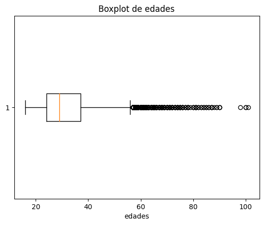

```python
#Utilizamos un boxplot para visualizar la distribución de las edades y detectar posibles valores atípicos:
# Para este caso, se observa datos atípicos en el rango de edad de '100'
plt.boxplot(df_copia['age'], vert=False)
plt.title('Boxplot de edades')
plt.xlabel('edades')
plt.show()
```

## **ANÁLISIS DE DATOS BIVARIADOS**

*Con la columna: 'used_premium_feature' --> Si el cliente usó la función premium de la aplicación, entonces 1 de lo contrario 0.*

```python
estadistica_con_uso_premium = df_copia.groupby('used_premium_feature')['age'].describe()
print(estadistica_con_uso_premium)
```

```
                        count       mean        std   min   25%   50%   75%  \
used_premium_feature
0                     41399.0  31.703181  10.952613  16.0  23.0  29.0  38.0
1                      8601.0  31.826299  10.053684  16.0  24.0  29.0  37.0

                        max
used_premium_feature
0                     101.0
1                      87.0
```

**Interpretación General:**

**Para el grupo con 'used_premium_feature' igual a 0:**

Count (Recuento): Hay 41,399 observaciones en este grupo.

Media (Mean): La edad promedio es aproximadamente 31.70 años.

Desviación Estándar (Std): La dispersión alrededor de la media es de aproximadamente 10.95 años, lo que indica una variabilidad moderada.

Mínimo (Min): La edad mínima es de 16 años.

25% (Percentil 25): El 25% de las edades son menores o iguales a 23 años.

50% (Mediana o Percentil 50): La mediana (valor en el medio) es de 29 años.

75% (Percentil 75): El 75% de las edades son menores o iguales a 38 años.

Máximo (Max): La edad máxima es de 101 años.

**Para el grupo con 'used_premium_feature' igual a 1:**

Count (Recuento): Hay 8,601 observaciones en este grupo.

Media (Mean): La edad promedio es aproximadamente 31.83 años.

Desviación Estándar (Std): La dispersión alrededor de la media es de aproximadamente 10.05 años, lo que indica una variabilidad similar pero ligeramente menor que el grupo 0.

Mínimo (Min): La edad mínima es de 16 años.

25% (Percentil 25): El 25% de las edades son menores o iguales a 24 años.

50% (Mediana o Percentil 50): La mediana es de 29 años.

75% (Percentil 75): El 75% de las edades son menores o iguales a 37 años.

Máximo (Max): La edad máxima es de 87 años.

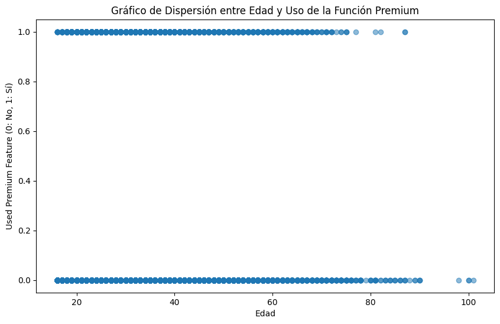

```python
plt.figure(figsize=(10, 6))
plt.scatter(df_copia['age'], df_copia['used_premium_feature'], alpha=0.5)
plt.title('Gráfico de Dispersión entre Edad y Uso de la Función Premium')
plt.xlabel('Edad')
plt.ylabel('Used Premium Feature (0: No, 1: Sí)')
plt.show()
```

## **VISUALIZACIÓN DE LOS DATOS**

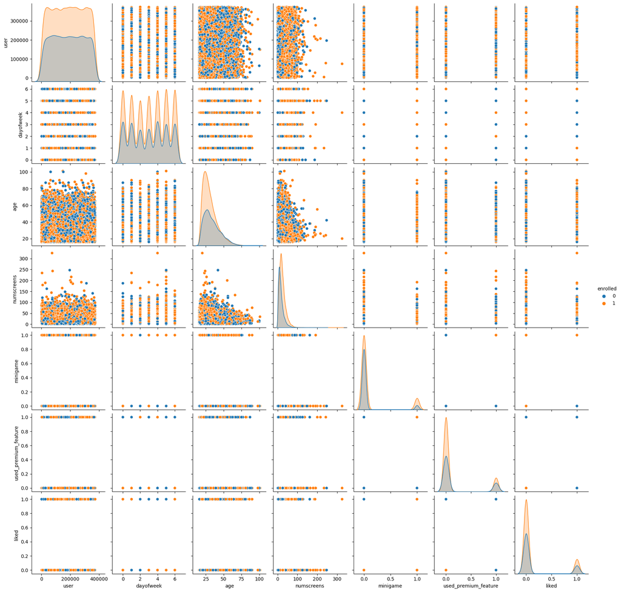

```python
sns.pairplot(df_copia, hue  = 'enrolled')
```

**Clientes PREMIUM -> 1 y NO PREMIUM -> 0**

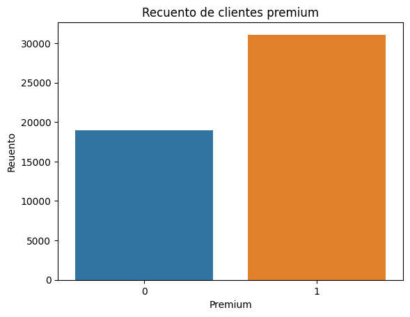

```python
sns.countplot(x='enrolled', data=df_copia)

plt.xlabel("Premium")
plt.ylabel("Reuento")
plt.title("Recuento de clientes premium")

plt.show()
```

[figure not shown]

```python
plt.hist([["enrolled"], ["age"], ["user"]], bins=10, color=['blue', 'green', 'red'], edgecolor='black', label=["enrolled", "age", "user"])

plt.title('Histograma de premium y edad')
plt.xlabel('Valores')
plt.ylabel('Frecuencia')
plt.legend()

plt.show()
```

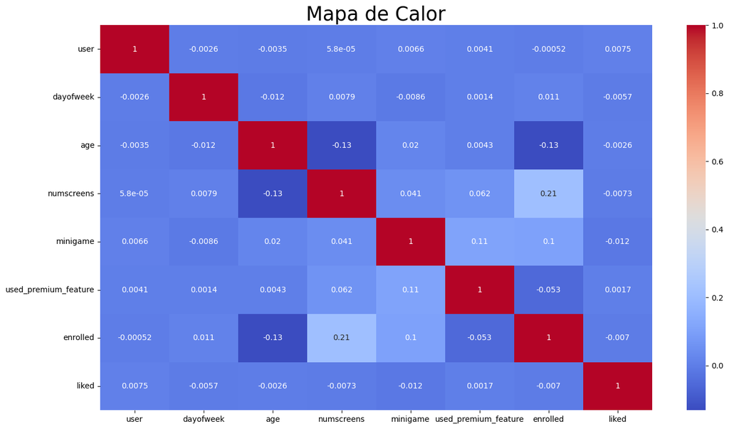

```python
plt.figure(figsize=(16,9)) # heatmap size in ratio 16:9

sns.heatmap(df_copia.corr(), annot = True, cmap ='coolwarm') # show heatmap

plt.title("Mapa de Calor", fontsize = 25) # title of heatmap
```